# SPCA Component LM Null Calibration

EYW

2026-08-21

# Goal

To assess calibration of our linear model scoring of ligand and interaction effects on sPCA components, we will calculate an empirical null-benchmark. As our screen includes 9 distinct barcoded non-targeting linker VLPs, we will treat these linker VLPs as stand ins for ligand1/ligand2 identities and perform an *identical* waggr-scoring + LM pipeline (`01_spca_waggr_scoring_null.ipynb` -> the LM fit below) to identify a null distribution of p-values for this linear model approach. This notebook fits the null LM itself and, alongside the null-only calibration checks, overlays the real analysis’s own component LM p-values (already computed by `spca_annotation.Rmd`) for a direct real-vs-null comparison.

# Import

```r
library(tidyverse)
library(scales)
```

```r
library(broom)
library(sandwich)   # robust vcov
knitr::opts_chunk$set(echo = TRUE)

source("../../functions/r_custom/plotting_fxns.R")
theme_set(theme_Publication())

null_dir <- "../../analysis_outs/spca/spca_null"
real_dir <- "../../analysis_outs/spca"
```

```r
# import real spca fit results
lmReal <- read_csv(file.path(real_dir, "lm_fit_zscore_degs_allLigands_0.1_alpha1.0_sPCA.csv"))
# import null spca fit results
codes <- read_csv(file.path(null_dir, "zscore_degs_null_0.1_alpha1.0_waggr_score.csv"))
codes <- codes %>% dplyr::mutate(replicate = str_extract(interaction, "rep[12]"))
```

# Fit the null LM

Same model as the real script: `loading ~ ligand1 * ligand2 + replicate`, fit per component with HC3 robust SEs, p-values BH-adjusted globally across all components/terms, using the most-abundant barcode per slot as the reference level (there is no principled “true zero” reference among 9 equally-null barcodes, unlike real `"linker"`).

```r
# center/scale and clean codes
mat <- codes %>%
  dplyr::mutate(across(where(is.numeric), ~ as.numeric(scale(.x)))) %>%
  column_to_rownames("interaction") %>%
  dplyr::select(where(is.numeric)) %>%
  as.matrix()

# Extract metadata from rownames: "{ligand1}_{ligand2}_{replicate}" - valid
# because the null pseudo-ligand tokens are underscore-free (see
# 01_spca_waggr_scoring_null.ipynb), exactly like real ligand names (IL2, CCL1, ...).
meta <- tibble(interaction = rownames(mat)) %>%
  separate(interaction, into = c("ligand1", "ligand2", "replicate"), sep = "_", remove = FALSE) %>%
  mutate(replicate = factor(replicate))

ref_ligand1 <- meta %>% count(ligand1, sort = TRUE) %>% slice(1) %>% pull(ligand1)
ref_ligand2 <- meta %>% count(ligand2, sort = TRUE) %>% slice(1) %>% pull(ligand2)
cat("Reference levels - ligand1:", ref_ligand1, " ligand2:", ref_ligand2, "\n")
```

```
## Reference levels - ligand1: linker2round1  ligand2: linker4round2
```

```r
meta <- meta %>%
  mutate(
    ligand1 = fct_relevel(ligand1, ref_ligand1),
    ligand2 = fct_relevel(ligand2, ref_ligand2)
  )

df <- as.data.frame(mat) %>%
  rownames_to_column("interaction") %>%
  left_join(meta, by = "interaction") %>%
  pivot_longer(cols = starts_with("comp"), names_to = "component", values_to = "loading") %>%
  mutate(ligand1 = factor(ligand1), ligand2 = factor(ligand2), replicate = factor(replicate))

.robust_vcov <- function(mod) sandwich::vcovHC(mod, type = "HC3")
.tidy_ols_hc <- function(mod) broom::tidy(mod, conf.int = TRUE, vcov = .robust_vcov(mod))

interaction_models <- df %>%
  group_by(component) %>%
  nest() %>%
  mutate(
    model_ols   = map(data, ~ lm(loading ~ ligand1 * ligand2 + replicate, data = .x)),
    tidy_ols_hc = map(model_ols, .tidy_ols_hc)
  )

lmFull <- interaction_models %>%
  dplyr::select(component, tidy_ols_hc) %>%
  unnest(tidy_ols_hc) %>%
  ungroup() %>%
  mutate(p_adj = p.adjust(p.value, method = "BH"))
```

# Pool p-values by contrast, real and null

```r
categorize_contrast <- function(term) {
  case_when(
    grepl("^ligand1.+:ligand2", term) ~ "ligand1:ligand2",
    grepl("^ligand1", term) ~ "ligand",
    grepl("^ligand2", term) ~ "ligand",
    TRUE ~ NA_character_
  )
}

nullPvals <- lmFull %>%
  mutate(contrast = categorize_contrast(term)) %>%
  filter(!is.na(contrast)) %>%
  rename(pvalue = p.value, adj_pval = p_adj) %>%
  filter(!is.na(pvalue)) %>%
  mutate(source = "null")

realPvals <- lmReal %>%
  mutate(contrast = categorize_contrast(term)) %>%
  filter(!is.na(contrast)) %>%
  rename(pvalue = p.value, adj_pval = p_adj) %>%
  filter(!is.na(pvalue)) %>%
  mutate(source = "real")

allPvals <- bind_rows(nullPvals, realPvals)
allPvals %>% count(source, contrast)
```

```
## # A tibble: 4 × 3
##   source contrast            n
##   <chr>  <chr>           <int>
## 1 null   ligand            546
## 2 null   ligand1:ligand2   468
## 3 real   ligand           5070
## 4 real   ligand1:ligand2 46332
```

# P-value distribution

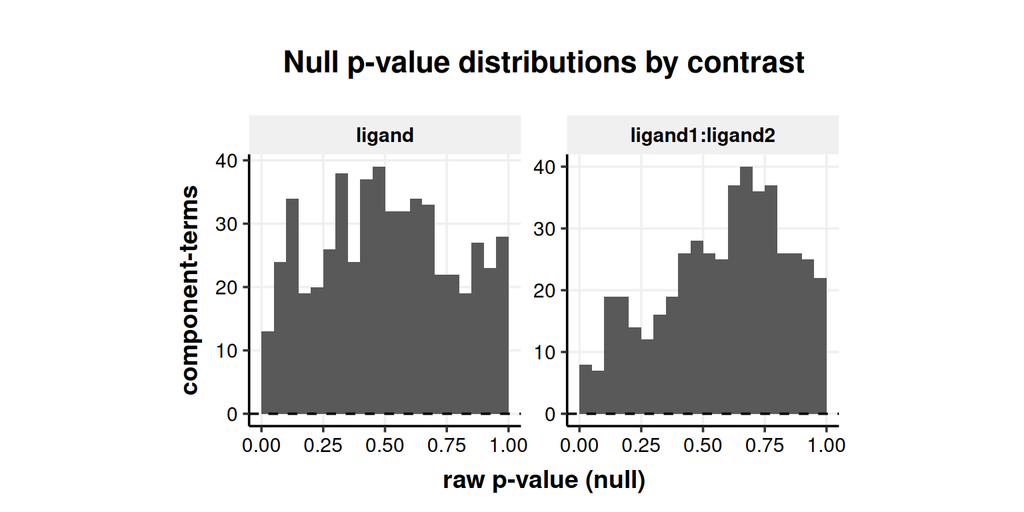

```r
ggplot(nullPvals, aes(x = pvalue)) +
  geom_histogram(breaks = seq(0, 1, by = 0.05), boundary = 0) +
  geom_hline(yintercept = 0, linetype = "dashed") +
  facet_wrap(~contrast, scales = "free_y") +
  labs(x = "raw p-value (null)", y = "component-terms", title = "Null p-value distributions by contrast") +
  theme(aspect.ratio = 1)
```

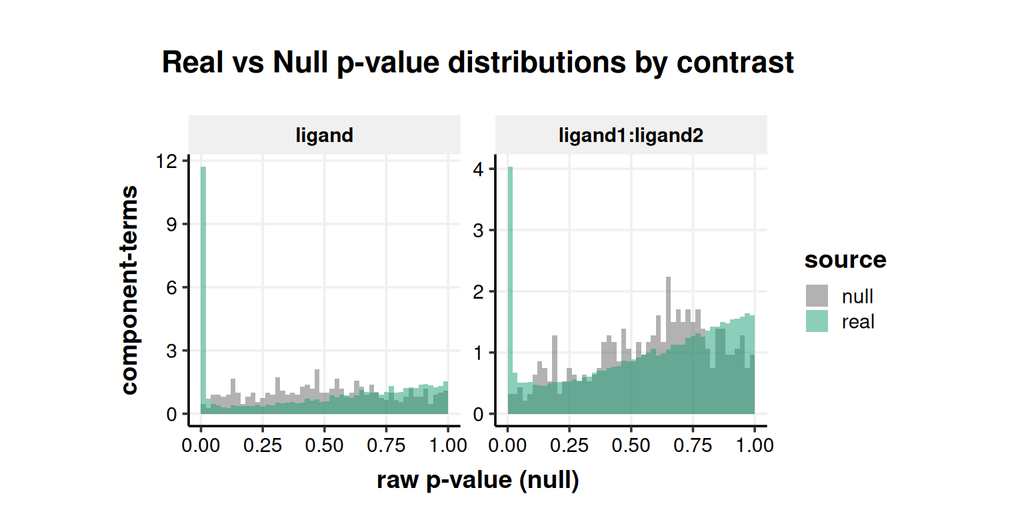

```r
ggsave("../../analysis_outs/plots/spca_null/spca_pval_histogram_null.pdf")
ggplot(allPvals, aes(x = pvalue, y = after_stat(density), fill = source)) +
  geom_histogram(breaks = seq(0, 1, by = 0.02), boundary = 0, position = "identity", alpha = 0.5) +
  scale_fill_manual(values = c("#666666FF","#1B9E77FF")) +
  facet_wrap(~contrast, scales = "free_y") +
  labs(x = "raw p-value (null)", y = "component-terms",
       title = "Real vs Null p-value distributions by contrast") +
  theme(aspect.ratio = 1)
```

```r
ggsave("../../analysis_outs/plots/spca_null/spca_pval_histogram_real_vs_null.pdf")
```

# QQ plots

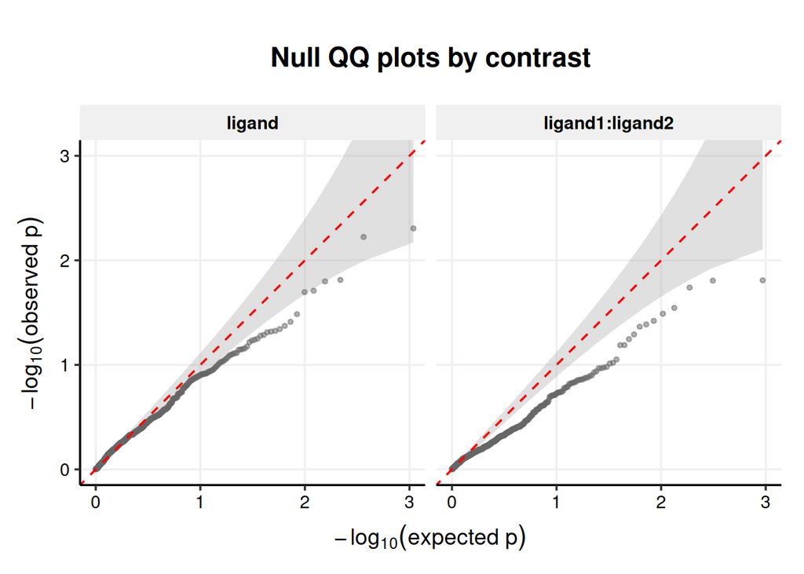

```r
qqData <- nullPvals %>%
  group_by(contrast) %>%
  arrange(pvalue, .by_group = TRUE) %>%
  mutate(
    n = n(),
    rank = row_number(),
    expected = -log10(ppoints(n)),
    observed = -log10(pvalue),
    # Beta distribution CI for each order statistic (on the p-value scale)
    ci_lower = qbeta(0.025, rank, n - rank + 1),
    ci_upper = qbeta(0.975, rank, n - rank + 1),
    # transform to -log10 scale; note bounds swap because -log10 is decreasing
    ci_lower_log = -log10(ci_upper),
    ci_upper_log = -log10(ci_lower)
  ) %>%
  ungroup()

ggplot(qqData, aes(x = expected, y = observed)) +
  geom_ribbon(aes(ymin = ci_lower_log, ymax = ci_upper_log),
              fill = "grey70", alpha = 0.4) +
  geom_point(alpha = 0.5, size = 1, color = "#666666FF") +
  geom_abline(slope = 1, intercept = 0, color = "red", linetype = "dashed") +
  facet_wrap(~contrast) +
  labs(x = expression(-log[10](expected~p)), y = expression(-log[10](observed~p)),
       title = "Null QQ plots by contrast") +
  coord_cartesian(xlim = c(0, 3), ylim = c(0, 3)) +
  theme(aspect.ratio = 1)
```

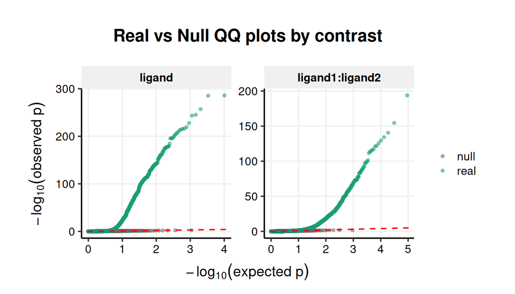

```r
ggsave("../../analysis_outs/plots/spca_null/spca_QQ_null.pdf")
qqDataBoth <- allPvals %>%
  group_by(source, contrast) %>%
  arrange(pvalue, .by_group = TRUE) %>%
  mutate(
    n = n(),
    expected = -log10(ppoints(n)),
    observed = -log10(pvalue),
  ) %>%
  ungroup()

ggplot(qqDataBoth, aes(x = expected, y = observed, color = source)) +
  geom_point(alpha = 0.5, size = 1) +
  geom_abline(slope = 1, intercept = 0, color = "red", linetype = "dashed") +
  scale_color_manual(values = c("#666666FF","#1B9E77FF")) +
  facet_wrap(~contrast, scales = "free") +
  labs(x = expression(-log[10](expected~p)), y = expression(-log[10](observed~p)), color = NULL,
       title = "Real vs Null QQ plots by contrast") +
  theme(aspect.ratio = 1)
```

```r
ggsave("../../analysis_outs/plots/spca_null/spca_QQ_real_vs_null.pdf")
```

# Empirical false-positive rate

Calculate the empirical false-positive rate using a significance threshold of `p_adj <= 0.1`.

```r
allPvals %>%
  filter(source == "null") %>%
  group_by(source, contrast) %>%
  summarise(
    n_tests = n(),
    n_sig = sum(adj_pval <= 0.1, na.rm = TRUE),
    empirical_fdr = n_sig / n_tests,
    .groups = "drop"
  ) %>%
  arrange(contrast, source)
```

```
## # A tibble: 2 × 5
##   source contrast        n_tests n_sig empirical_fdr
##   <chr>  <chr>             <int> <int>         <dbl>
## 1 null   ligand              546     0             0
## 2 null   ligand1:ligand2     468     0             0
```